```r
setwd("C:\\Users\\panch\\Documents\\Coursework\\Hackathon 2022")
```

#Loading Data

```r
data = read.csv("C:\\Users\\panch\\Documents\\Coursework\\Hackathon 2022\\data.csv")
scoringdata = read.csv("C:\\Users\\panch\\Documents\\Coursework\\Hackathon 2022\\scoringData.csv")
```

#Finding na cloumns in data and scoring data

```r
na = is.na(data)
sumofna = colSums(is.na(data))
colsumofna = colSums(is.na(data)) > 0
namesofcolswithna = colnames(data)[colSums(is.na(data)) > 0]
namesofcolswithna
```

```
## [1] "number_of_ingredients"
```

```r
na = is.na(scoringdata)
sumofna = colSums(is.na(scoringdata))
colsumofna = colSums(is.na(scoringdata)) > 0
namesofcolswithna = colnames(scoringdata)[colSums(is.na(scoringdata)) > 0]
namesofcolswithna
```

```
## [1] "number_of_ingredients"
```

#Replacing NA values with mean of the columns in data and scoringdata

```r
data[is.na(data$number_of_ingredients),]$number_of_ingredients <- mean(data$number_of_ingredients, na.rm = T)
scoringdata[is.na(scoringdata$number_of_ingredients),]$number_of_ingredients <- mean(scoringdata$number_of_ingredients, na.rm = T)
```

#Converting categorical variables which are important to factor variables of data and scoringData

```r
data$company_location = as.factor(data$company_location)
data$country_of_bean_origin = as.factor(data$country_of_bean_origin)

scoringdata$company_location = as.factor(scoringdata$company_location)
scoringdata$country_of_bean_origin = as.factor(scoringdata$country_of_bean_origin)
```

#Cleaning company location in data and scoringdata

```r
library(forcats)
data$company_location = fct_collapse(data$company_location, Europe = c("Belgium","France","Italy","U.K."),
                                                            S.America = c("Ecuador"),
                                                            N.America = c("Canada","U.S.A."))
scoringdata$company_location = fct_collapse(scoringdata$company_location, Europe = c("Belgium","France","Italy","U.K."),
                                                            S.America = c("Ecuador"),
                                                            N.America = c("Canada","U.S.A."))
```

#Forming Binary Variables from Boolean Variable Columns in data and scoringdata

```r
data$sweet_binary <- ifelse(data$sweet == 'Yes', 1, 0)
data$nutty_binary <- ifelse(data$nutty == 'Yes', 1, 0)
data$cocoa_binary <- ifelse(data$cocoa == 'Yes', 1, 0)
data$roasty_binary <- ifelse(data$roasty == 'Yes', 1, 0)
data$earthy_binary <- ifelse(data$earthy == 'Yes', 1, 0)
data$creamy_binary <- ifelse(data$creamy == 'Yes', 1, 0)
data$sandy_binary <- ifelse(data$sandy == 'Yes', 1, 0)
data$fatty_binary <- ifelse(data$fatty == 'Yes', 1, 0)
data$floral_binary <- ifelse(data$floral == 'Yes', 1, 0)
data$intense_binary <- ifelse(data$intense == 'Yes', 1, 0)
data$sour_binary <- ifelse(data$sour == 'Yes', 1, 0)
data$vanilla_binary <- ifelse(data$vanilla == 'Yes', 1, 0)
data$fruit_binary <- ifelse(data$fruit == 'Yes', 1, 0)
data$molasses_binary <- ifelse(data$molasses == 'Yes', 1, 0)
data$woody_binary <- ifelse(data$woody == 'Yes', 1, 0)
data$sticky_binary <- ifelse(data$sticky == 'Yes', 1, 0)
data$coffee_binary <- ifelse(data$coffee == 'Yes', 1, 0)
data$rich_binary <- ifelse(data$rich == 'Yes', 1, 0)
data$dried.fruit_binary <- ifelse(data$dried.fruit == 'Yes', 1, 0)
data$ingredient_Beans_binary <- ifelse(data$ingredient_Beans == 'Yes', 1, 0)
data$ingredient_Sugar_binary <- ifelse(data$ingredient_Sugar == 'Yes', 1, 0)
data$ingredient_Sweetener_binary <- ifelse(data$ingredient_Sweetener == 'Yes', 1, 0)
data$ingredient_Cocoa_Butter_binary <- ifelse(data$ingredient_Cocoa_Butter == 'Yes', 1, 0)
data$ingredient_vanilla_binary <- ifelse(data$ingredient_vanilla == 'Yes', 1, 0)
data$ingredient_lecithin_binary <- ifelse(data$ingredient_lecithin == 'Yes', 1, 0)
data$ingredient_salt <- ifelse(data$ingredient_salt == 'Yes', 1, 0)


scoringdata$sweet_binary <- ifelse(scoringdata$sweet == 'Yes', 1, 0)
scoringdata$nutty_binary <- ifelse(scoringdata$nutty == 'Yes', 1, 0)
scoringdata$cocoa_binary <- ifelse(scoringdata$cocoa == 'Yes', 1, 0)
scoringdata$roasty_binary <- ifelse(scoringdata$roasty == 'Yes', 1, 0)
scoringdata$earthy_binary <- ifelse(scoringdata$earthy == 'Yes', 1, 0)
scoringdata$creamy_binary <- ifelse(scoringdata$creamy == 'Yes', 1, 0)
scoringdata$sandy_binary <- ifelse(scoringdata$sandy == 'Yes', 1, 0)
scoringdata$fatty_binary <- ifelse(scoringdata$fatty == 'Yes', 1, 0)
scoringdata$floral_binary <- ifelse(scoringdata$floral == 'Yes', 1, 0)
scoringdata$intense_binary <- ifelse(scoringdata$intense == 'Yes', 1, 0)
scoringdata$sour_binary <- ifelse(scoringdata$sour == 'Yes', 1, 0)
scoringdata$vanilla_binary <- ifelse(scoringdata$vanilla == 'Yes', 1, 0)
scoringdata$fruit_binary <- ifelse(scoringdata$fruit == 'Yes', 1, 0)
scoringdata$molasses_binary <- ifelse(scoringdata$molasses == 'Yes', 1, 0)
scoringdata$woody_binary <- ifelse(scoringdata$woody == 'Yes', 1, 0)
scoringdata$sticky_binary <- ifelse(scoringdata$sticky == 'Yes', 1, 0)
scoringdata$coffee_binary <- ifelse(scoringdata$coffee == 'Yes', 1, 0)
scoringdata$rich_binary <- ifelse(scoringdata$rich == 'Yes', 1, 0)
scoringdata$dried.fruit_binary <- ifelse(scoringdata$dried.fruit == 'Yes', 1, 0)
scoringdata$ingredient_Beans_binary <- ifelse(scoringdata$ingredient_Beans == 'Yes', 1, 0)
scoringdata$ingredient_Sugar_binary <- ifelse(scoringdata$ingredient_Sugar == 'Yes', 1, 0)
scoringdata$ingredient_Sweetener_binary <- ifelse(scoringdata$ingredient_Sweetener == 'Yes', 1, 0)
scoringdata$ingredient_Cocoa_Butter_binary <- ifelse(scoringdata$ingredient_Cocoa_Butter == 'Yes', 1, 0)
scoringdata$ingredient_vanilla_binary <- ifelse(scoringdata$ingredient_vanilla == 'Yes', 1, 0)
scoringdata$ingredient_lecithin_binary <- ifelse(scoringdata$ingredient_lecithin == 'Yes', 1, 0)
scoringdata$ingredient_salt <- ifelse(scoringdata$ingredient_salt == 'Yes', 1, 0)
```

```r
numericVars <- which(sapply(data, is.numeric))
data_numVar <- data[,numericVars]
cor_numVar <- cor(data_numVar)
cor_sorted <- as.matrix(sort(cor_numVar[,'rating'], decreasing = TRUE))

(cor_sorted)
```

```
##                                        [,1]
## rating                          1.000000000
## cocoa_binary                    0.184586697
## creamy_binary                   0.174881623
## ingredient_Beans_binary         0.163995585
## ingredient_Sugar_binary         0.161273549
## rich_binary                     0.147902395
## fruit_binary                    0.105405065
## dried.fruit_binary              0.092839754
## nutty_binary                    0.087402193
## floral_binary                   0.042184254
## ingredient_Cocoa_Butter_binary  0.038752326
## coffee_binary                   0.015916957
## roasty_binary                   0.009410362
## sticky_binary                   0.002107573
## intense_binary                 -0.009174344
## id                             -0.010549373
## woody_binary                   -0.022559731
## ingredient_salt                -0.049589713
## ingredient_lecithin_binary     -0.052455365
## sandy_binary                   -0.063230193
## fatty_binary                   -0.071534437
## molasses_binary                -0.077762903
## earthy_binary                  -0.102111734
## number_of_ingredients          -0.104095869
## sweet_binary                   -0.123928565
## sour_binary                    -0.124193406
## cocoa_percent                  -0.135078972
## ingredient_vanilla_binary      -0.155153723
## vanilla_binary                 -0.172064646
```

```r
#png(filename = "mycorrplot.png", width = 1200, height = 800)
#corrplot(cor_numVar, type = "lower",)
```

#Stating the column types in the data

```r
NumericVars <- which(sapply(data, is.numeric)) #index vector numeric variables
FactorVars <- which(sapply(data, is.factor)) #index vector factor variables
CharacterVars <- which(sapply(data, is.character)) #index vector character variables

cat('There are', length(NumericVars), 'numeric variables, and', length(FactorVars), 'factor variables, and',length(CharacterVars),'character variables')
```

```
## There are 30 numeric variables, and 2 factor variables, and 26 character variables
```

#Subsetting data and scoring data to make models

```r
DATA = subset(data ,select = c(rating,cocoa_binary,creamy_binary,ingredient_Beans_binary,rich_binary,fruit_binary,earthy_binary,number_of_ingredients,sweet_binary,sour_binary,cocoa_percent,ingredient_vanilla_binary,vanilla_binary,company_location,dried.fruit_binary,nutty_binary,fatty_binary,molasses_binary))

SCORINGDATA = subset(scoringdata,select = c(cocoa_binary,creamy_binary,ingredient_Beans_binary,rich_binary,fruit_binary,earthy_binary,number_of_ingredients,sweet_binary,sour_binary,cocoa_percent,ingredient_vanilla_binary,vanilla_binary,company_location,dried.fruit_binary,nutty_binary,fatty_binary,molasses_binary))

SCORINGDATA$rating = NA
```

#Splitting the data into test and train

```r
library(caret)
set.seed(617)
split<-createDataPartition(DATA$rating,p = 0.75 ,list=FALSE,groups = 100)
train<-DATA[split,]
test<-DATA[-split,]
```

#Best linear regression

```r
model_lm = lm(rating ~ . , train)

pred_lm_train = predict(model_lm)
rmse_lm_train = sqrt(mean((pred_lm_train - train$rating)^2))

pred_lm = predict(model_lm , newdata = test)
rmse_lm_test = sqrt(mean((pred_lm - test$rating)^2))



rmse_lm_train ; rmse_lm_test
```

```
## [1] 0.3917873
```

```
## [1] 0.3902121
```

```r
model_glm = glm(rating ~ ., train , family = 'inverse.gaussian')

pred_glm_train = predict(model_glm, type='response')
rmse_glm_train = sqrt(mean((pred_glm_train - train$rating)^2)) #70.82915

pred_glm_test = predict(model_glm , newdata = test , type = 'response')
rmse_glm_test = sqrt(mean((pred_glm_test - test$rating)^2)) #71.19982

#pred_glm_SCORING = predict(model_lm , newdata = SCORINGDATA , type = 'response')

rmse_glm_train ; rmse_glm_test
```

```
## [1] 0.3934722
```

```
## [1] 0.3920613
```

```r
#(test rmse : 70.13889 , rmse after uploading : 69.96191)
```

#Best decision tree selection

```r
library(rpart)
model_tree = rpart(rating ~ . , train , method ='anova', control = rpart.control(cp = 4e-04))

pred_tree_train = predict(model_tree)
rmse_tree_train = sqrt(mean((pred_tree_train - train$rating)^2)) #65.26914

pred_tree_test = predict(model_tree , newdata = test)
rmse_tree_test = sqrt(mean((pred_tree_test - test$rating)^2)) #68.48148

#pred_tree_SCORING = predict(model_tree , newdata = SCORINGDATA)

rmse_tree_train ; rmse_tree_test
```

```
## [1] 0.3647868
```

```
## [1] 0.41404
```

#Best Ranger model

```r
library(ranger)
set.seed(617)
ranger = ranger(rating~.,
                       data = train,
                       num.trees = 3000)

pred_ranger_train = predict(ranger, data = train, num.trees = 3000)
rmse_ranger_train = sqrt(mean((pred_ranger_train$predictions - train$rating)^2))


pred_ranger_test = predict(ranger , test , num.trees = 3000)
rmse_ranger_test = sqrt(mean((pred_ranger_test$predictions - test$rating)^2))


rmse_ranger_train ; rmse_ranger_test
```

```
## [1] 0.3347724
```

```
## [1] 0.3852495
```

#Preparing data in a matrix format to feed in the XGboost model

```r
library(vtreat)
trt = designTreatmentsZ(dframe = train,
                        varlist = names(train)[2:18])
```

```
## [1] "vtreat 1.6.3 inspecting inputs Sun Nov 13 01:02:58 2022"
## [1] "designing treatments Sun Nov 13 01:02:58 2022"
## [1] " have initial level statistics Sun Nov 13 01:02:58 2022"
## [1] " scoring treatments Sun Nov 13 01:02:58 2022"
## [1] "have treatment plan Sun Nov 13 01:02:58 2022"
```

```r
newvars = trt$scoreFrame[trt$scoreFrame$code%in% c('clean','lev'),'varName']

train_input = prepare(treatmentplan = trt,
                      dframe = train,
                      varRestriction = newvars)

test_input = prepare(treatmentplan = trt,
                     dframe = test,
                     varRestriction = newvars)

SCORING_input = prepare(treatmentplan = trt,
                     dframe = SCORINGDATA,
                     varRestriction = newvars)
```

#Best XGboost model

```r
library(xgboost)
set.seed(617)
xgboost12 <- xgboost(data = as.matrix(train_input),
               label = train$rating,
               eta = 0.001,gamma=0,
               max_depth = 3,
               nround=6000,
               objective="reg:squarederror",
               early_stopping_rounds=50,
               print_every_n=1000,
               subsample = 0.5,
               )
```

```
## Will train until train_rmse hasn't improved in 50 rounds.
##
```

```r
pred_xgb12_train = predict(xgboost12 , newdata = as.matrix(train_input))
rmse_xgb12_train = sqrt(mean((pred_xgb12_train - train$rating)^2))

pred_xgb12_test = predict(xgboost12 , newdata = as.matrix(test_input))
rmse_xgb12_test = sqrt(mean((pred_xgb12_test - test$rating)^2))

rmse_xgb12_train ; rmse_xgb12_test
```

```
## [1] 0.3726872
```

```
## [1] 0.3826181
```

Best Gradient Boosting Model

```r
library(gbm)
set.seed(617)
boost = gbm(rating~.,
            data=train,
            distribution="gaussian",
            n.trees = 3000,
            interaction.depth = 2,
            shrinkage = 0.01)


pred_gbm_train = predict(boost , train )
```

```
## Using 3000 trees...
```

```r
rmse_gbm_train = sqrt(mean((pred_gbm_train - train$rating)^2))

pred_gbm_test = predict(boost , newdata = test )
```

```
## Using 3000 trees...
```

```r
rmse_gbm_test = sqrt(mean((pred_gbm_test - test$rating)^2))


pred_gbm_SCORING = predict(boost , newdata = SCORINGDATA)
```

```
## Using 3000 trees...
```

```r
rmse_gbm_train ; rmse_gbm_test
```

```
## [1] 0.3740611
```

```
## [1] 0.3807268
```

#Displaying the results of the Gradient Boosting Model

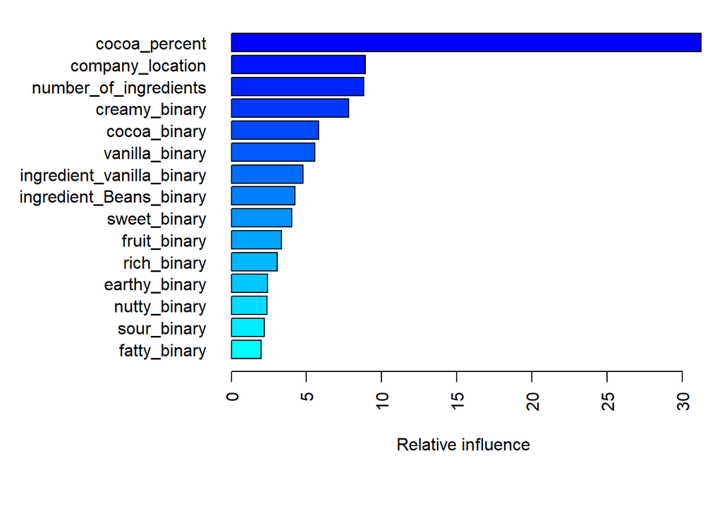

```
##                                                 var   rel.inf
## cocoa_percent                         cocoa_percent 31.272864
## company_location                   company_location  8.913749
## number_of_ingredients         number_of_ingredients  8.800192
## creamy_binary                         creamy_binary  7.818837
## cocoa_binary                           cocoa_binary  5.812054
## vanilla_binary                       vanilla_binary  5.571116
## ingredient_vanilla_binary ingredient_vanilla_binary  4.759542
## ingredient_Beans_binary     ingredient_Beans_binary  4.233907
## sweet_binary                           sweet_binary  4.022233
## fruit_binary                           fruit_binary  3.338729
## rich_binary                             rich_binary  3.069871
## earthy_binary                         earthy_binary  2.392468
## nutty_binary                           nutty_binary  2.389915
## sour_binary                             sour_binary  2.190249
## fatty_binary                           fatty_binary  1.995916
## dried.fruit_binary               dried.fruit_binary  1.969539
## molasses_binary                     molasses_binary  1.448819
```

```r
par(mar = c(7, 11, 1, 1))
summary(
  boost,
  cBars = 15,
  method = relative.influence, # also can use permutation.test.gbm
  las = 2
  )
```

#Finding the relationship of cocoa percent and rating of chocolate

```r
model = lm(rating ~ cocoa_percent,data)
summary(model)
```

```
##
## Call:
## lm(formula = rating ~ cocoa_percent, data = data)
##
## Residuals:
##      Min       1Q   Median       3Q      Max
## -2.21583 -0.24864  0.03417  0.28417  0.98103
##
## Coefficients:
##                Estimate Std. Error t value Pr(>|t|)
## (Intercept)    3.981403   0.124749  31.915  < 2e-16 ***
## cocoa_percent -0.010937   0.001739  -6.289 3.87e-10 ***
## ---
## Signif. codes:  0 '***' 0.001 '**' 0.01 '*' 0.05 '.' 0.1 ' ' 1
##
## Residual standard error: 0.4408 on 2128 degrees of freedom
## Multiple R-squared:  0.01825,    Adjusted R-squared:  0.01778
## F-statistic: 39.55 on 1 and 2128 DF,  p-value: 3.87e-10
```

#Finding the relationship of company location and rating of chocolate

```r
model = lm(rating ~ relevel(company_location,ref='Other'),data)
summary(model)
```

```
##
## Call:
## lm(formula = rating ~ relevel(company_location, ref = "Other"),
##     data = data)
##
## Residuals:
##     Min      1Q  Median      3Q     Max
## -2.1960 -0.2071  0.0429  0.3040  0.9348
##
## Coefficients:
##                                                   Estimate Std. Error t value
## (Intercept)                                        3.19603    0.01905 167.734
## relevel(company_location, ref = "Other")Australia  0.21468    0.07105   3.021
## relevel(company_location, ref = "Other")Europe    -0.02226    0.02952  -0.754
## relevel(company_location, ref = "Other")N.America  0.01106    0.02323   0.476
## relevel(company_location, ref = "Other")S.America -0.13082    0.06812  -1.920
##                                                   Pr(>|t|)
## (Intercept)                                        < 2e-16 ***
## relevel(company_location, ref = "Other")Australia  0.00255 **
## relevel(company_location, ref = "Other")Europe     0.45091
## relevel(company_location, ref = "Other")N.America  0.63397
## relevel(company_location, ref = "Other")S.America  0.05496 .
## ---
## Signif. codes:  0 '***' 0.001 '**' 0.01 '*' 0.05 '.' 0.1 ' ' 1
##
## Residual standard error: 0.4436 on 2125 degrees of freedom
## Multiple R-squared:  0.007194,   Adjusted R-squared:  0.005325
## F-statistic: 3.849 on 4 and 2125 DF,  p-value: 0.00403
```

#Finding the relationship of number_of_ingredients and rating of chocolate

```r
model = lm(rating ~ number_of_ingredients,data)
summary(model)
```

```
##
## Call:
## lm(formula = rating ~ number_of_ingredients, data = data)
##
## Residuals:
##      Min       1Q   Median       3Q      Max
## -2.19918 -0.25352  0.04809  0.29809  0.90132
##
## Coefficients:
##                       Estimate Std. Error t value Pr(>|t|)
## (Intercept)            3.35675    0.03401  98.685  < 2e-16 ***
## number_of_ingredients -0.05161    0.01069  -4.828 1.48e-06 ***
## ---
## Signif. codes:  0 '***' 0.001 '**' 0.01 '*' 0.05 '.' 0.1 ' ' 1
##
## Residual standard error: 0.4425 on 2128 degrees of freedom
## Multiple R-squared:  0.01084,    Adjusted R-squared:  0.01037
## F-statistic: 23.31 on 1 and 2128 DF,  p-value: 1.476e-06
```

#Making predictions and forming the submission file

```r
pred_gbm_SCORING = predict(boost , newdata = SCORINGDATA)
```

```
## Using 3000 trees...
```

```r
id = scoringdata$id
predicted_rating = pred_gbm_SCORING
file = data.frame(id , predicted_rating)

sub1 = write.csv(x = file , file = 'TeamADA.csv' , row.names = F)
```